# Communicating your findings effectively and reproducibly using charts produced with R and ggplot2

Tess Grynoch

May 2024

## Brief Introduction to R and RStudio

The term “R” is used to refer to both the programming language and the software that interprets the scripts written using it.

RStudio is currently a very popular way to not only write your R scripts but also to interact with the R software. To function correctly, RStudio needs R and therefore both need to be installed on your computer.

To make it easier to interact with R, we will use RStudio. RStudio is the most popular IDE (Integrated Development Interface) for R. An IDE is a piece of software that provides tools to make programming easier.

Reasons to use R:

- Easy to reproduce (less pointing and clicking)
- Able to analyze data and create visualizations without altering the data we input into our script regardless of the analysis we run
- Analysis and visualization possibilities are limitless and cross disciplinary boundaries
- Works on all types and sizes of data
- Open source
- Large and welcoming community

## Create a new project

- Under the File menu > New Project > New directory > New project > Choose a location for a folder for today’s workshop and give it a descriptive name > Create project (This is now our working directory)
- It’s good practice to keep all related data, analysis, and text in the same folder in order to use relative paths as opposed to the full path to the file’s location. Another best practice is to create a separate folders for your data, data outputs, and figure outputs. So let’s create two folders in our working directory named:
  - data
  - charts
- Create a new file where we will type our script. Go to File > New File > R script OR click the plus sign hovering over the white rectangle in the toolbar. Click the save icon on your tooolbar, or, in the menu, File > Save As and save your script as “DataViz-R-class-20240515.R”

Start by giving our document a title using a comment which are denoted by a #

```r
#Introduction to Data Visualization with R and ggplot2
#Instructor: Tess Grynoch
#Notes by Name

#Comments allow you to add notes as you write your code
```

Notice how after we start making changes the file name in the tab turns red and has an * beside it. It’s a reminder that we have not saved the new changes to the document yet. As we go along, remember to hit the save icon or control + s (On PC) or command + s (On Mac).

### Install packages and add libraries

To expand on what is already available through RStudio, we need to install packages. Today we’ll be using tidyverse which is a collection of R packages for data science including ggplot2. For more information on the packages, visit the [tidyverse website](https://www.tidyverse.org/).

```r
install.packages("tidyverse")
```

Once we install the package, we need to tell it which libraries we will be using

```r
library(tidyverse)
```

### Process of creating a data visualization

1. Identify your question/goal
2. Identify the audience for your results
3. Collect and analyze data needed
4. Choose appropriate visualization(s) to meet the needs of your question, audience, and data (sketch it out)
5. Apply good design concepts
6. Edit as necessary

For today, the first three steps have been completed already and we’re ready to move onto step 4. View the cleaning steps in the [class GitHub repository](https://github.com/grynoch/intro-dataviz-r).

### The research question

Based on the 2019 Nature PhD Students Survey, Which country has the most respondents who are studying in the same country they grew up in?

[Download the data for this class](https://github.com/grynoch/intro-dataviz-r/blob/main/data/Nature_PhDsurvey_Anon_v2.csv) using the download icon on the GitHub page.

The [original data and full text of the survey](https://figshare.com/s/74a5ea79d76ad66a8af8?file=18543278) is available on Figshare. We will be using a version that has been modified to more easily create the charts for this class.

### Reading files into R

To use data in R and RStudio we must first read it into the environment and assign it a variable name.

```r
phdsurvey <- read.csv("data/Nature_PhDsurvey_Anon_v2.csv")
```

I’ve used the relative path to the file above but if I were to use the full destination name it would look something like “C://Users/grynochc/Desktop/DataVizR-202208/data/Nature_PhDsurvey_Anon_v2.csv”

You can read other files into R using similar functions such as:

```r
#Excel files
library(readxl)
read_xlsx

#SAS, SPSS, STATA files
library(haven)
read_sas()
read_spss()
read_stata()
```

### Choosing a chart type

Resources:

- [Andrew Abela’s Chart Chooser](https://extremepresentation.typepad.com/files/choosing-a-good-chart-09.pdf)
- [Juice Analytics Chart Chooser](https://www.juiceanalytics.com/chartchooser)
- [Data Visualization Catalogue](https://datavizcatalogue.com/)
- [Stephanie Evergreen’s Qualitative Chart Chooser](http://stephanieevergreen.com/wp-content/uploads/2017/11/Qualitative-Chooser-3.pdf)

Important to keep in mind that some visual channels are more effective than others

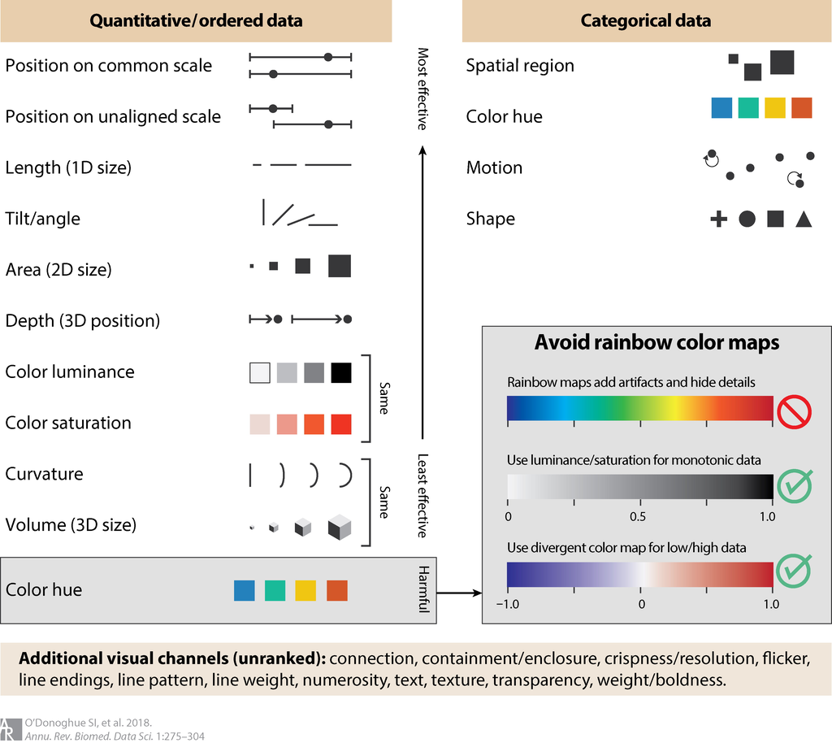

Copyright © 2018 Seán I. O’Donoghue et al. This work is licensed under a CC-BY 4.0 International License

**Based on our research question and the data available? What type of chart should we create?**